# Stat 343: Mathematical Statistics

## Cancer at the Slater School

The Slater school is an elementary school in Fresno, California where teachers and staff were "concerned about the presence of two high-voltage transmission lines that ran past the school …" They were particularly concerned about possibly increased cancer rates: out of 145 teachers, teachers' aides, and staff, 8 developed invasive cancer.

- Public health questions:
  - What can we say about the risk of cancer among employees at the Slater school?
  - Is this risk higher than the risk among similar people nationwide?
- Example discussed in Brodeur (1992) and Lavine (1999)

## A Basic Analysis (see Intro Stat)

- Let \(X\) = number of teachers and staff who become sick.
- Model \(X \sim \text{Binomial}(145, p)\)
- Point estimate for \(p\): \[\widehat{p} = \frac{8}{145} \approx 0.055\]
- A 95% Confidence Interval for \(p\): \[\left[\widehat{p} - 1.96 \sqrt{\frac{\widehat{p} (1 - \widehat{p})}{n}}, \widehat{p} + 1.96 \sqrt{\frac{\widehat{p} (1 - \widehat{p})}{n}}\right]\] \[[0.018, 0.092]\]

## Three More Methods

- All based on the same Binomial model

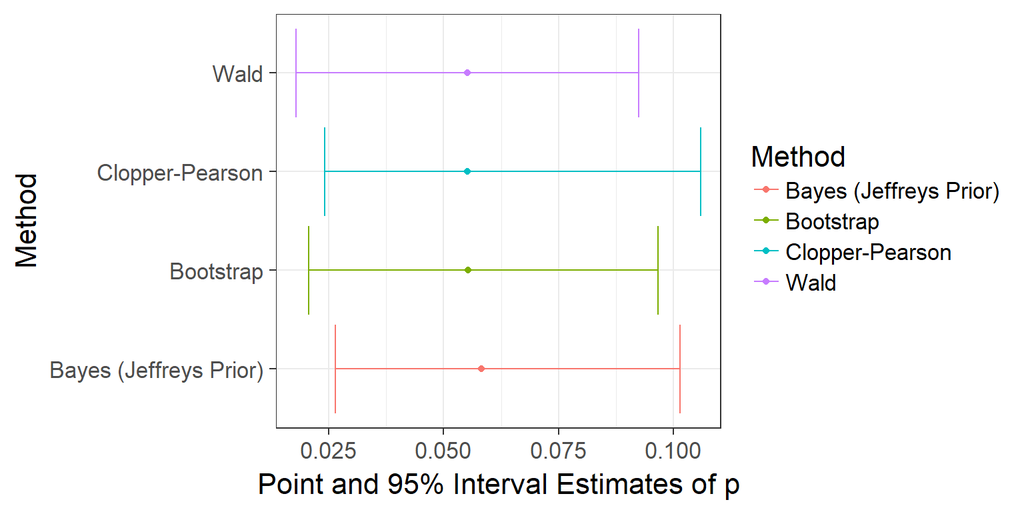

## Comparing These Approaches

- In Stat 343 we will discuss:
  - Common methods for deriving estimators for model parameters
  - Common methods for estimating uncertainty in our parameter estimates
  - Asymptotic Results
    - As \(n\) increases, do the estimates converge to the true values?
    - As \(n\) increases, some methods have "optimal" performance – in what sense?
  - If sample sizes are small, are some methods more reliable than others?